# MARINe_GDM

MARINe_GDM Erica Nielsen 2023-12-19

## Generalized Dissimarity Models Analyses for PCI

This markdown takes biodiversity data from MARINe rocky shore long term monitoring & satellite environmental data to run GDMs to map community structure for the present dat & 2050.

```r
library(readxl)

#read point contact
pt_cont <- read_excel("C:/Users/erica.nielsen/Desktop/Synz/MARINe/large_biodiv_data/cbs_data_CA_2023.xlsx",
    sheet = "point_contact_summary_data")

#read quadrat summary
quad <- read_excel("C:/Users/erica.nielsen/Desktop/Synz/MARINe/large_biodiv_data/cbs_data_CA_2023.xlsx",
    sheet = "quadrat_summary_data")

#read swath data
swath <- read_excel("C:/Users/erica.nielsen/Desktop/Synz/MARINe/large_biodiv_data/cbs_data_CA_2023.xlsx",
    sheet = "swath_summary_data")
```

The input data to make ‘site-pair’ tables for GDMs -> Rows = sites, Columns = spp abundance. To do this we need to do the following:

```r
#see if there's overlapping spp between three tables
intersect(intersect(pt_cont$species_lump, quad$species_lump), swath$species_lump)
```

```
## character(0)
```

```r
character(0) # so there's no species overlap between tables
```

```
## character(0)
```

The next problem is that we need one ‘spp_abund’ count for the present day and we have multiple abundances per species (per year)– will try and average spp abundaces over the years that the environmental data is available for (I checked the air temp data from MARINe but it doesn’t exist for all biodiv sites so will need to use other data)

- WorldClim Version 2 = 1970-2000, so not the best temporal range to match data –> looking into air temp for same range, and this seems like a good option:

  https://climatedataguide.ucar.edu/climate-data/airs-atmospheric-infrared-sounder-version-6-level-2 download here: https://disc.gsfc.nasa.gov/datasets?page=1&source=AQUA%20AIRS,AQUA%20AMSU-A,AQUA%20HSB date range=2002-09-01 to 2014-09-01 spatial range= xmin= -126, xmax= -116, ymin = 32, ymax= 42 probs want surfAir_A and _D and get average across those (A=daytime, D=nighttime)
- Bio-Oracle version 2 = 2000-2014

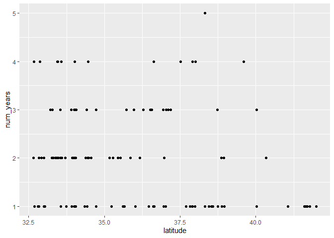

```r
library(dplyr)
library(ggplot2)

#filter by year per DF

quad_yr<-quad%>% filter(between(year, 2000, 2014))
swath_yr<-swath%>% filter(between(year, 2000, 2014))
pt_cont_yr<-pt_cont%>% filter(between(year, 2000, 2014))

#now see how many years each site was sampled for
  # think I might want to filter to include only sites with 3+ years... or run analyses on all data vs. filtered data

## QUAD
yrs_quad<-quad_yr %>% group_by(marine_site_name,latitude) %>% count(year, sort = TRUE)

yrs_quad<-yrs_quad %>%
    group_by(marine_site_name) %>%
    add_count(name = "num_years")

ggplot(yrs_quad, aes(x=latitude, y=num_years)) + geom_point()
```

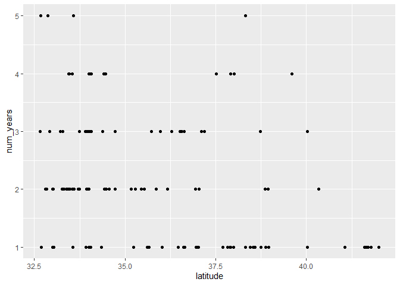

```r
#a lot of the northern sites only have 1 year collected for quad


## SWATH
yrs_swath<-swath_yr %>% group_by(marine_site_name,latitude) %>% count(year, sort = TRUE)

yrs_swath<-yrs_swath %>%
    group_by(marine_site_name) %>%
    add_count(name = "num_years")

ggplot(yrs_swath, aes(x=latitude, y=num_years)) + geom_point()
```

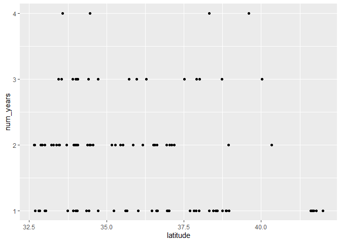

```r
# similar pattern in swath

## PT Cont
yrs_pt_cont<-pt_cont_yr %>% group_by(marine_site_name,latitude) %>% count(year, sort = TRUE)

yrs_pt_cont<-yrs_pt_cont %>%
    group_by(marine_site_name) %>%
    add_count(name = "num_years")

ggplot(yrs_pt_cont, aes(x=latitude, y=num_years)) + geom_point()
```

```r
#even fewer years for the pt_cont data
```

-Looks like doing >3 years per site would yield very low sample sizes… think that we can try comparing 1 vs. 2 years sampling and see if there’s difference

- What I could also do is not filter the data to 2000-2014, then apply 3+ year filter and see if outputs differ (only thing then is that the climate data misses 2015-2023)

```r
## Starting with no number of yrs filter

#average abundance per species over the years per site
quad_avg <- quad_yr %>%
     group_by(marine_site_name, latitude, longitude, species_lump) %>%
     summarize(Mean = mean(density_per_m2, na.rm=FALSE))

pt_cont_avg <- pt_cont_yr %>%
     group_by(marine_site_name, latitude, longitude, species_lump) %>%
     summarize(Mean = mean(percent_cover, na.rm=FALSE))

swath_avg <- swath_yr %>%
     group_by(marine_site_name, latitude, longitude, species_lump) %>%
     summarize(Mean = mean(density_per_m2, na.rm=FALSE))

#join data frames
common_col_names <- intersect(names(quad_avg), names(pt_cont_avg)) #get column names
quad_pt<-merge(quad_avg, pt_cont_avg, by=common_col_names, all.x=TRUE, all.y=TRUE) #merge first 2 DFs
quad_pt_swath<-merge(quad_pt, swath_avg, by=common_col_names, all.x=TRUE, all.y=TRUE) #merge in swath
```

So now we have a ‘x-y species list’ dataframe (which is bioFormat=2 for GDM, i.e. spp are rows and not columns)

Last step before we can make a ‘site-pair’ table is to get the environmental predictor variables

```r
library(sdmpredictors)
library(raster)
library(psych)
```

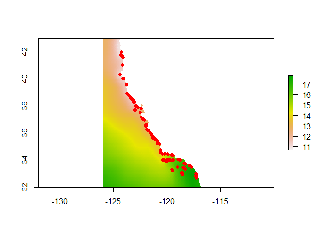

```r
#view available layers
marine_lyrs<- list_layers(datasets=c(), terrestrial = F, marine = T, freshwater =
  F, monthly = TRUE, version = NULL)

#download marine features
mar.env.pres <- load_layers( layercodes = c("BO22_tempmean_ss", "BO22_salinitymean_ss", "BO22_curvelmean_ss") , datadir = 'C:/Users/erica.nielsen/Desktop/Synz/MARINe/PCI_MARINe_synth/GDM', equalarea=FALSE, rasterstack=TRUE)

#investigate which layers are available for future
mar.env.fut <-list_layers_future(datasets = c(), scenario = NA, year = NA,
  terrestrial = F, marine = T, freshwater = F, monthly = TRUE, version =
  NULL)
# we have SST, SSS, current velocity for 2050 & 2100

#Crop layers to US West Coast extent
WC.ext <- extent(-126, -116, 32, 43)
mar.env.pres.c <- crop(mar.env.pres, WC.ext)

## Check extent
#get long and lat
lat_longs<- unique(quad_pt_swath[,c(3,2)])

plot(mar.env.pres.c$BO22_tempmean_ss)

points(lat_longs[,1:2], pch=19, col="red")
```

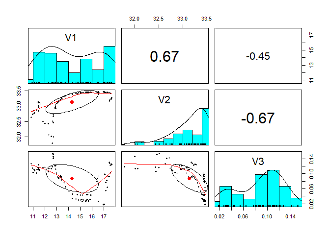

```r
mar.env.pres.c <- stack(mar.env.pres.c)

#Extract values when there's NAs (sometimes coastal points won't align with ocean or air raster layers, so we extract nearest possible point from raster)
sample_raster_NA <- function(r, xy){
  apply(X = xy, MARGIN = 1,
        FUN = function(xy) r@data@values[which.min(replace(distanceFromPoints(r, xy), is.na(r), NA))])

}

test<-lapply(mar.env.pres.c@layers, function(a_layer) sample_raster_NA(a_layer, cbind(lat_longs$longitude, lat_longs$latitude)))

envdat.whole <-as.data.frame(do.call(cbind, test))
env.data.pres <- cbind2(x=lat_longs, y=envdat.whole)

#Get env var correlations (want to exclude any of those >0.7)
pairs.panels(envdat.whole, scale=T)
```

Okay now we have mean sea surface temp, salinity, and current velocity for site coords. Now we need to combine with species table and convert to site-pair table for GDM

```r
library(gdm)

xy_col_names <- intersect(names(quad_pt_swath), names(env.data.pres)) #get column names

GDM_spp_env <-merge(quad_pt_swath, env.data.pres, by=, all.x=TRUE, all.y=TRUE) #merge spp and env data matching my lat long

#going to do a bit or re-naming now... will sites and spp will get codes, so will have to back to GDM_spp_env metadata
GDM_spp_env <- GDM_spp_env %>% group_by(marine_site_name) %>% mutate(site=cur_group_id())

GDM_spp_env <- GDM_spp_env %>% group_by(species_lump) %>% mutate(species=cur_group_id())

GDM_spp_env$species = paste0('spp', GDM_spp_env$species)

GDM_sppTab <- GDM_spp_env[, c(1,2,5,9,10)]

GDM_sppTab$species <- as.factor(GDM_sppTab$species)

# Env data need to be separate DF.. (needs to also have sites, lat & long)
GDM_envTab <- GDM_spp_env[, c(9,1,2,6:8)]
#add env col names
names(GDM_envTab)[4] <- "SST"
names(GDM_envTab)[5] <- "SSS"
names(GDM_envTab)[6] <- "Curvel"

# format site-pair
gdmTab <- formatsitepair(bioData=GDM_sppTab,
                         abundance=TRUE,
                         bioFormat=2, #x-y spp list
                         XColumn="longitude",
                         YColumn="latitude",
                         sppColumn="species",
                         siteColumn="site",
                         abundColumn="Mean",
                         predData=GDM_envTab)

#gives error... check! maybe it doesn't like spaces in the site and spp names?? -- nope was because I didn't have lat + longs for both spp and env datasets
```

```r
#run GDM on our data
gdm.1 <- gdm(data=gdmTab, geo=TRUE) #geo=T means we want distance btwn sites to be included as model term

# check out model with summary
summary(gdm.1)
```

```
## [1]
## [1]
## [1] GDM Modelling Summary
## [1] Creation Date:  Wed Jan  3 13:21:24 2024
## [1]
## [1] Name:  gdm.1
## [1]
## [1] Data:  gdmTab
## [1]
## [1] Samples:  8001
## [1]
## [1] Geographical distance used in model fitting?  TRUE
## [1]
## [1] NULL Deviance:  1076.327
## [1] GDM Deviance:  1033.061
```

[output cut: 45 more lines]

```r
# we see low % deviance explained of ~4 (ie. goodnes-of-fit)

# intercept is 0.65, which means that sites that don't differ in predictors can have this amount of dissimilarity

# Summary of the fitted I-splines is reported for each predictor. The sum indicates the amount of compositional turnover associated with that variable, holding all other variables constant. I-spline summaries are order by coefficient sum. Variables with all coefficients=0 have no relationship with the modeled biological pattern

## looks like SSS has no relationship to biological pattern
```

```r
length(gdm.1$predictors) # get ideal of number of panels
```

```
## [1] 4
```

[output not shown]

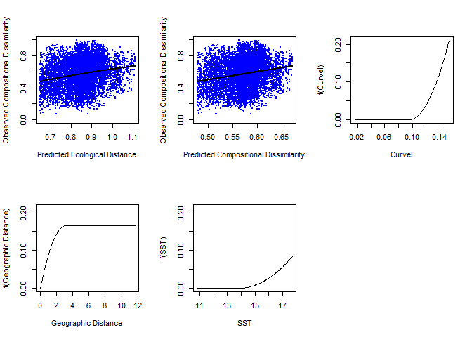

```r
plot(gdm.1, plot.layout=c(2,3))

# displays summary plots showing (i) the fitted relationship between predicted ecological distance and observed compositional dissimilarity and (ii) predicted versus observed biological distance, followed by a series of panels showing each I-spline with at least one non-zero coefficient (plotted in order by sum of the I-spline coefficients).

# The spline’s shape indicates how the rate of biological change varies with position along that gradient. Thus, the splines provide insight into the total magnitude of biological change as a function of each gradient and where along each gradient those changes are most pronounced. Here we see that the most change happens going from mid to high values of current velocity
```

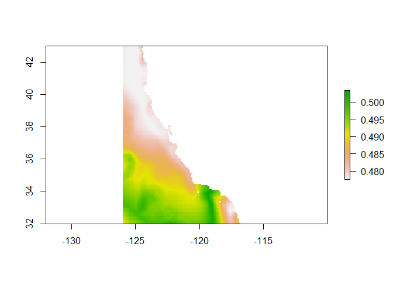

```r
# will need to first download future env vars
mar.env.2050 <- load_layers( layercodes = c("BO2_RCP85_2050_tempmean_ss", "BO2_RCP85_2050_salinitymean_ss", "BO2_RCP85_2050_curvelmean_ss") , datadir = 'C:/Users/erica.nielsen/Desktop/Synz/MARINe/PCI_MARINe_synth/GDM', equalarea=FALSE, rasterstack=TRUE)

#crop
mar.env.2050.c <- crop(mar.env.2050, WC.ext)

#rename raster layers to be same as in the model
names(mar.env.2050.c)[1] <- 'SST'
names(mar.env.2050.c)[2] <- 'SSS'
names(mar.env.2050.c)[3] <- 'Curvel'

names(mar.env.pres.c)[1] <- 'SST'
names(mar.env.pres.c)[2] <- 'SSS'
names(mar.env.pres.c)[3] <- 'Curvel'


#have to re-stack now
mar.env.2050.c <- stack(mar.env.2050.c)
mar.env.pres.c <- stack(mar.env.pres.c)


# here we use the GDM model to first predict onto the present day, and then into the future -- pretty sure raster layer names must be the same!
timePred <- predict(gdm.1, mar.env.pres.c, time=TRUE, predRasts=mar.env.2050.c) #time=T means that we predict into new timeframe

# by plotting we see the expected magnitude of change in vegetation composition, which can be interpreted as a biologically-scaled metric of climate stress
raster::plot(timePred)
```